# White Wine Quality Analysis by Priyaranjan JC.

Data set contains white variants of the Portuguese “Vinho Verde” wine. Number of Instances of white wine - 4898. Number of Attributes: 11 + output attribute(quality)

**Description for Atrributes and Output Variable :**

- *X :* serial number for instances.
- *fixed acidity:* most acids involved with wine or fixed or nonvolatile (do not evaporate readily)
- *volatile acidity:* the amount of acetic acid in wine, which at too high of levels can lead to an unpleasant, vinegar taste
- *citric acid:* found in small quantities, citric acid can add ‘freshness’ and flavor to wines
- *residual sugar:* the amount of sugar remaining after fermentation stops, it’s rare to find wines with less than 1 gram/liter and wines with greater than 45 grams/liter are considered sweet.
- *chlorides:* the amount of salt in the wine
- *free sulfur dioxide:* the free form of SO2 exists in equilibrium between molecular SO2 (as a dissolved gas) and bisulfite ion; it prevents microbial growth and the oxidation of wine
- *total sulfur dioxide:* amount of free and bound forms of S02; in low concentrations, SO2 is mostly undetectable in wine, but at free SO2 concentrations over 50 ppm, SO2 becomes evident in the nose and taste of wine
- *density:* the density of water is close to that of water depending on the percent alcohol and sugar content
- *pH:* describes how acidic or basic a wine is on a scale from 0 (very acidic) to 14 (very basic); most wines are between 3-4 on the pH scale
- *sulphates:* a wine additive which can contribute to sulfur dioxide gas (S02) levels, which acts as an antimicrobial and antioxidant
- *alcohol:* the percent alcohol content of the wine
- *quality :* Contains a score between 0 and 10.

# Univariate Plots Section

```
## 'data.frame':    4898 obs. of  12 variables:
##  $ fixed.acidity       : num  7 6.3 8.1 7.2 7.2 8.1 6.2 7 6.3 8.1 ...
##  $ volatile.acidity    : num  0.27 0.3 0.28 0.23 0.23 0.28 0.32 0.27 0.3 0.22 ...
##  $ citric.acid         : num  0.36 0.34 0.4 0.32 0.32 0.4 0.16 0.36 0.34 0.43 ...
##  $ residual.sugar      : num  20.7 1.6 6.9 8.5 8.5 6.9 7 20.7 1.6 1.5 ...
##  $ chlorides           : num  0.045 0.049 0.05 0.058 0.058 0.05 0.045 0.045 0.049 0.044 ...
##  $ free.sulfur.dioxide : num  45 14 30 47 47 30 30 45 14 28 ...
##  $ total.sulfur.dioxide: num  170 132 97 186 186 97 136 170 132 129 ...
##  $ density             : num  1.001 0.994 0.995 0.996 0.996 ...
##  $ pH                  : num  3 3.3 3.26 3.19 3.19 3.26 3.18 3 3.3 3.22 ...
##  $ sulphates           : num  0.45 0.49 0.44 0.4 0.4 0.44 0.47 0.45 0.49 0.45 ...
##  $ alcohol             : num  8.8 9.5 10.1 9.9 9.9 10.1 9.6 8.8 9.5 11 ...
##  $ quality             : int  6 6 6 6 6 6 6 6 6 6 ...
```

```
##  fixed.acidity    volatile.acidity  citric.acid     residual.sugar
##  Min.   : 3.800   Min.   :0.0800   Min.   :0.0000   Min.   : 0.600
##  1st Qu.: 6.300   1st Qu.:0.2100   1st Qu.:0.2700   1st Qu.: 1.700
##  Median : 6.800   Median :0.2600   Median :0.3200   Median : 5.200
##  Mean   : 6.855   Mean   :0.2782   Mean   :0.3342   Mean   : 6.391
##  3rd Qu.: 7.300   3rd Qu.:0.3200   3rd Qu.:0.3900   3rd Qu.: 9.900
##  Max.   :14.200   Max.   :1.1000   Max.   :1.6600   Max.   :65.800
##    chlorides       free.sulfur.dioxide total.sulfur.dioxide
##  Min.   :0.00900   Min.   :  2.00      Min.   :  9.0
##  1st Qu.:0.03600   1st Qu.: 23.00      1st Qu.:108.0
##  Median :0.04300   Median : 34.00      Median :134.0
##  Mean   :0.04577   Mean   : 35.31      Mean   :138.4
##  3rd Qu.:0.05000   3rd Qu.: 46.00      3rd Qu.:167.0
##  Max.   :0.34600   Max.   :289.00      Max.   :440.0
##     density             pH          sulphates         alcohol
##  Min.   :0.9871   Min.   :2.720   Min.   :0.2200   Min.   : 8.00
##  1st Qu.:0.9917   1st Qu.:3.090   1st Qu.:0.4100   1st Qu.: 9.50
##  Median :0.9937   Median :3.180   Median :0.4700   Median :10.40
##  Mean   :0.9940   Mean   :3.188   Mean   :0.4898   Mean   :10.51
##  3rd Qu.:0.9961   3rd Qu.:3.280   3rd Qu.:0.5500   3rd Qu.:11.40
##  Max.   :1.0390   Max.   :3.820   Max.   :1.0800   Max.   :14.20
##     quality
##  Min.   :3.000
##  1st Qu.:5.000
##  Median :6.000
##  Mean   :5.878
##  3rd Qu.:6.000
##  Max.   :9.000
```

```
##                              [,1]
## fixed.acidity        -0.113662831
## volatile.acidity     -0.194722969
## citric.acid          -0.009209091
## residual.sugar       -0.097576829
## chlorides            -0.209934411
## free.sulfur.dioxide   0.008158067
## total.sulfur.dioxide -0.174737218
## density              -0.307123313
## pH                    0.099427246
## sulphates             0.053677877
## alcohol               0.435574715
## quality               1.000000000
```

#### Wine Quality

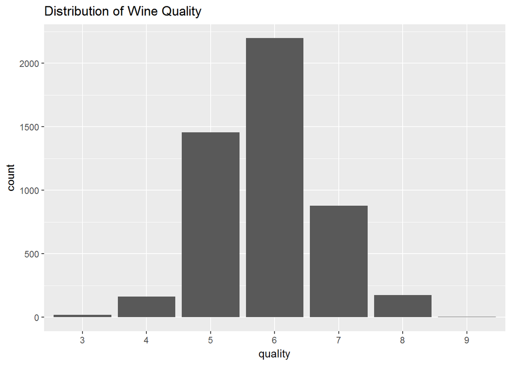

Quality variable is unbalanced.It follows a normal distribution.Wine having quality 6 is the most common wine.

#### Fixed.Acidity

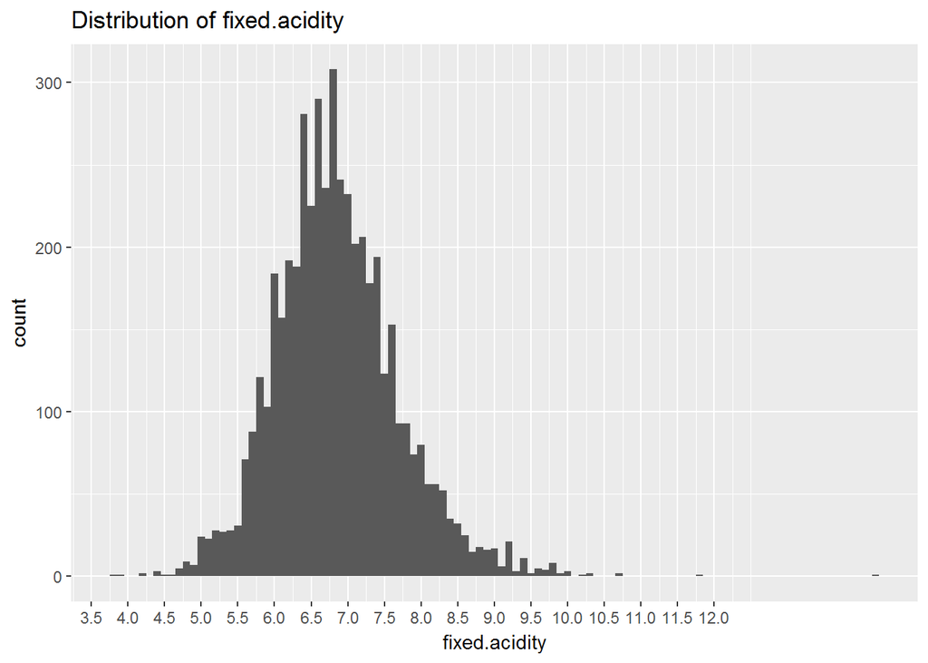

fixed acidity ranges between 3.8 and 14.2. But most of the values are distributed acrsoo 5.5 to 8.5 range. Considering only 0.95 quantile data(removing outliers) for visualization.

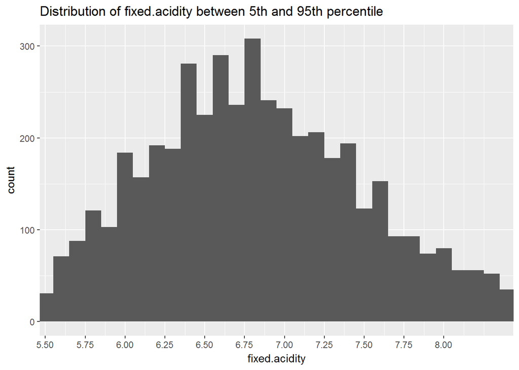

Fixed acidity property of the wine follows mostly a normal distribution between 5th and 95th percentile of the values.

#### Volatile Acidity

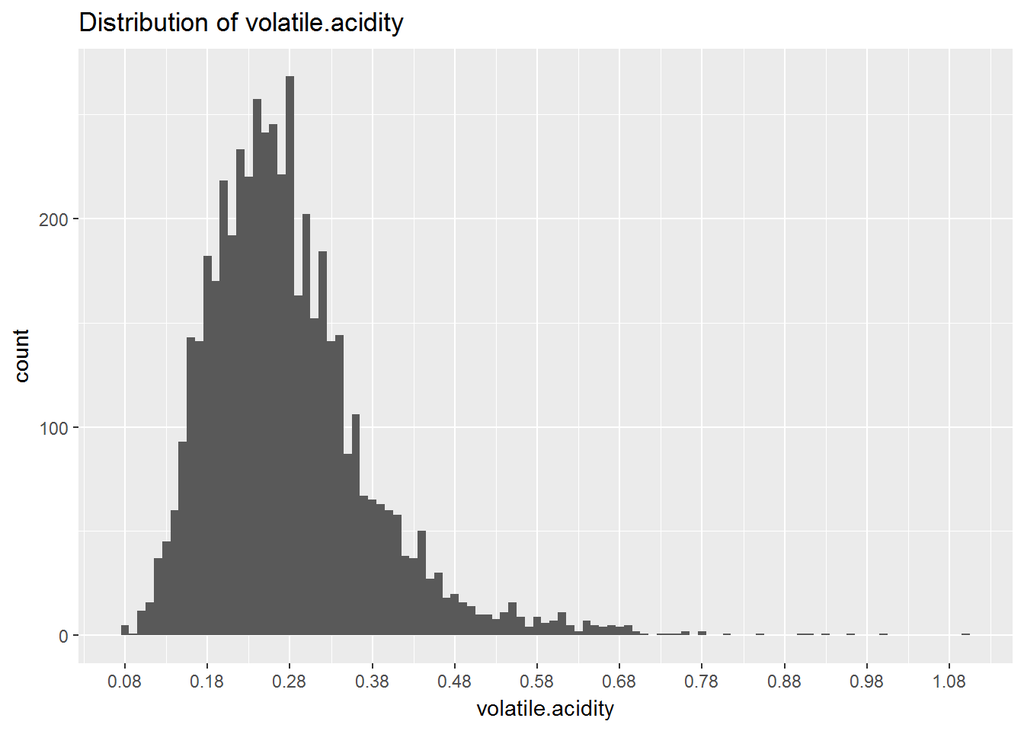

High amounts of volatile.acidity will make the wine taste like vinegar.So,most of the acidity is below 0.48 percent.

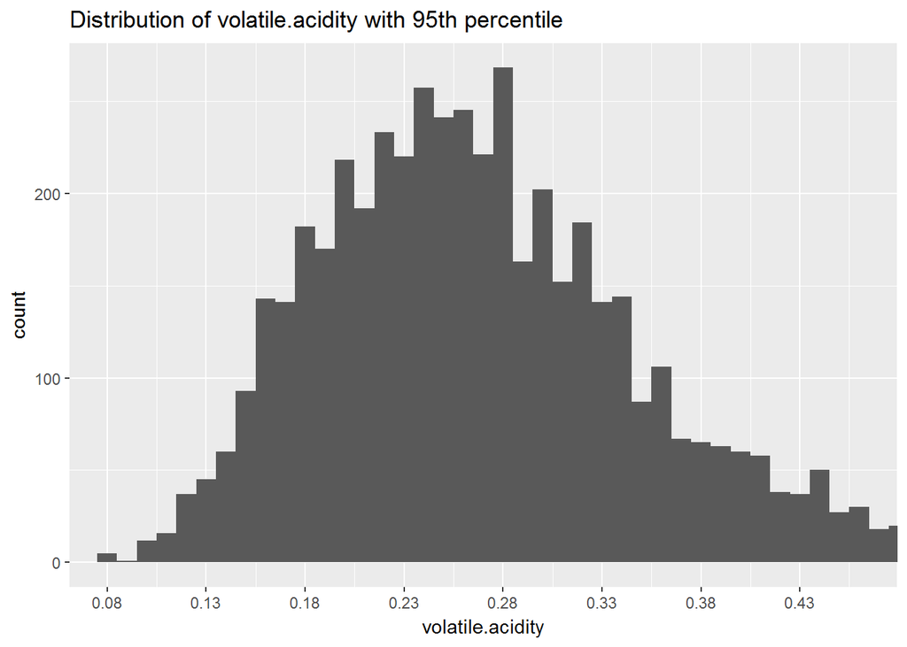

After removing outliers(95th percent quantile),we can observe that volatile.acidity follows a near normal distribution. In futher investigation we need to find if acidity above 0.48 will result in low quality wines.

#### Citric Acid

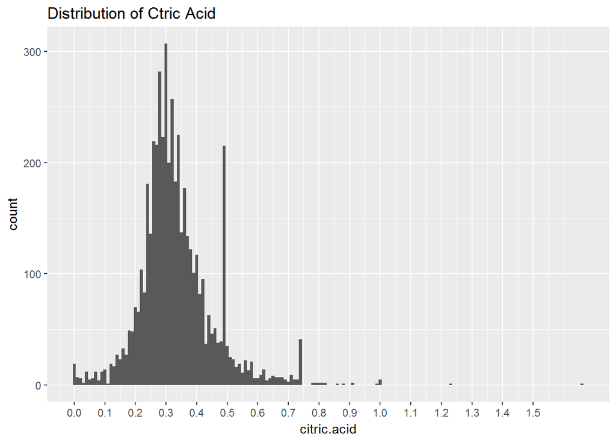

Citric acid is in very low quantitles when compared to fixed acid percent.It is more in the range of volatile acid range.There are few wines with nearly zero citirc acid percent. Range of citric acid is between 0.00 and 1.66.But most the values reside between 0.2 and 0.5.

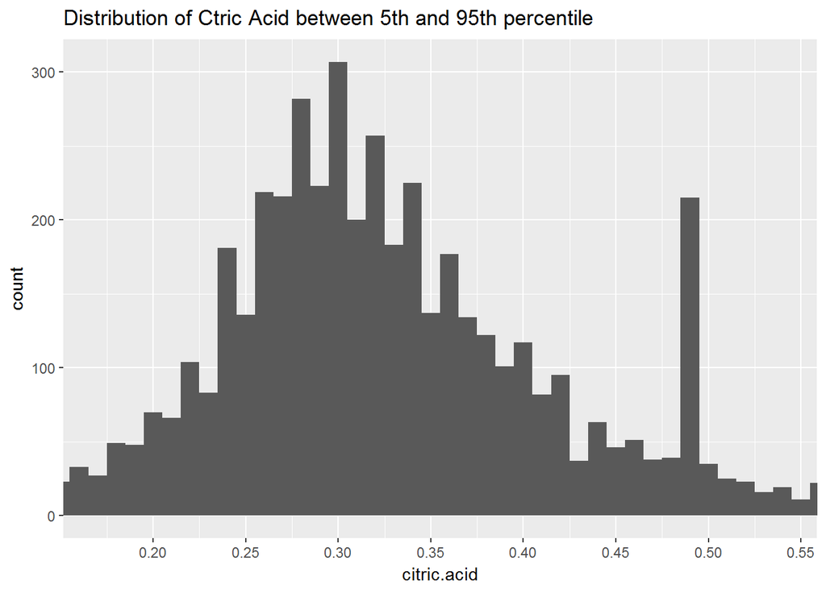

Between 5th and 95th percentile, citric acid moslty follows normal distribution.

#### Residual sugar

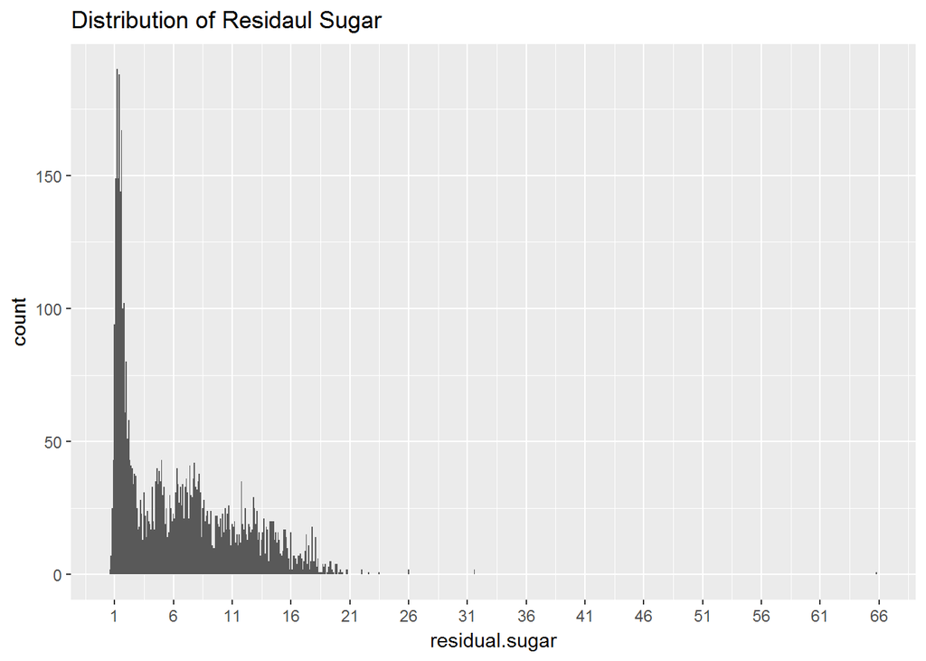

Most of the values in Resudual sugar are between 0-20.But there are few very large values.

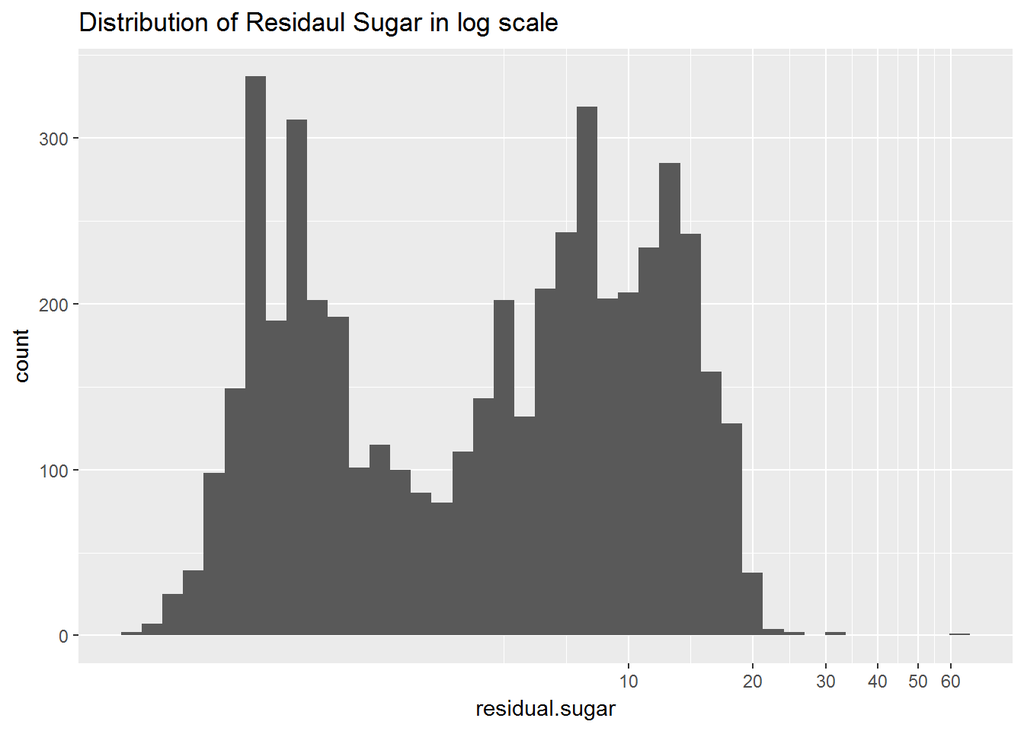

In log x axis scale, residual sugar follows a bimodal distribution.

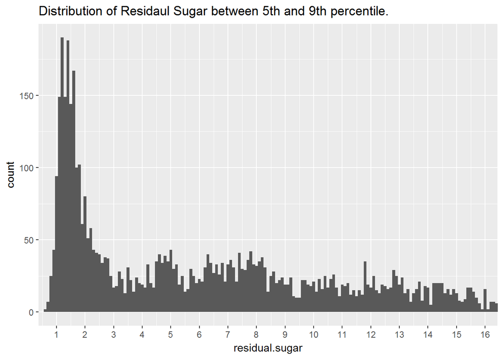

Lot of the wines has residual sugar values of around 1.5 and residual values are uniformly distributed from 3 to 16.

#### chlorides

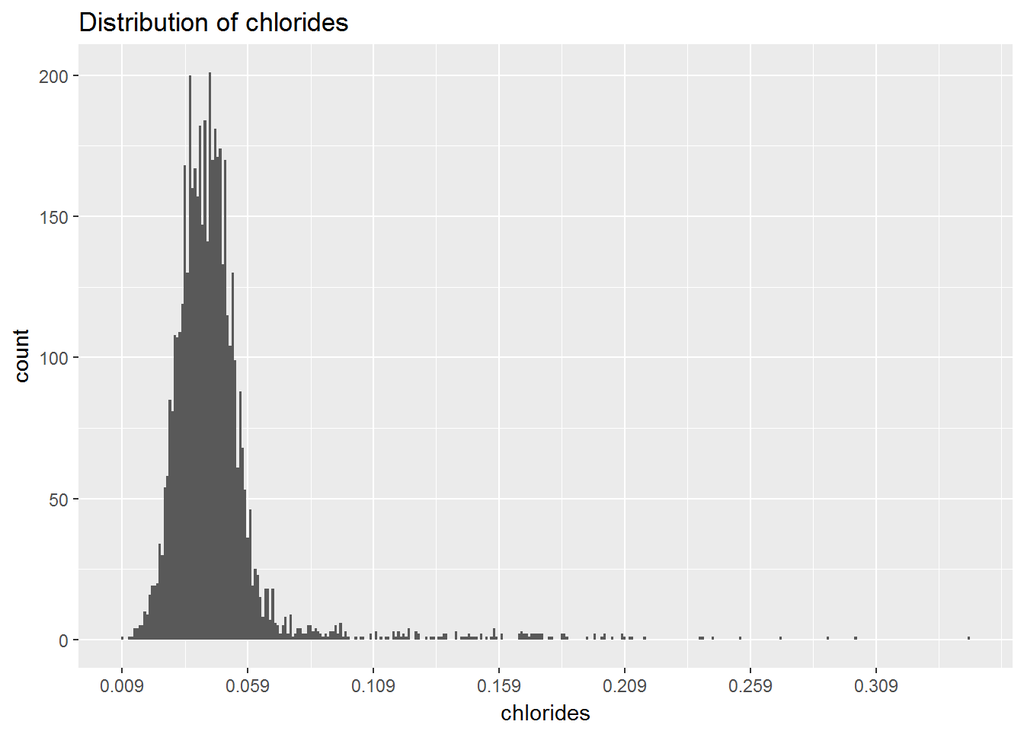

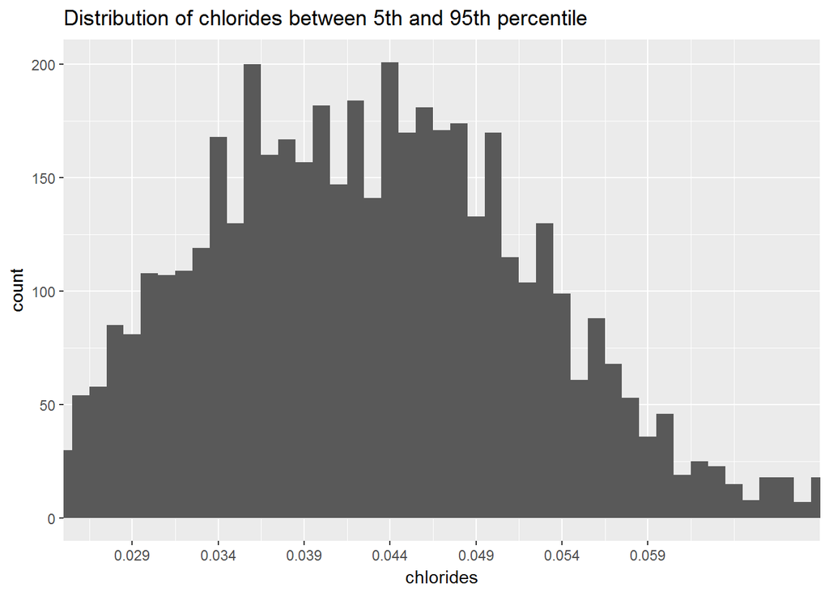

Chlorides between 5th and 95th percentile has normal distribution.

#### Free sulphur dioxide

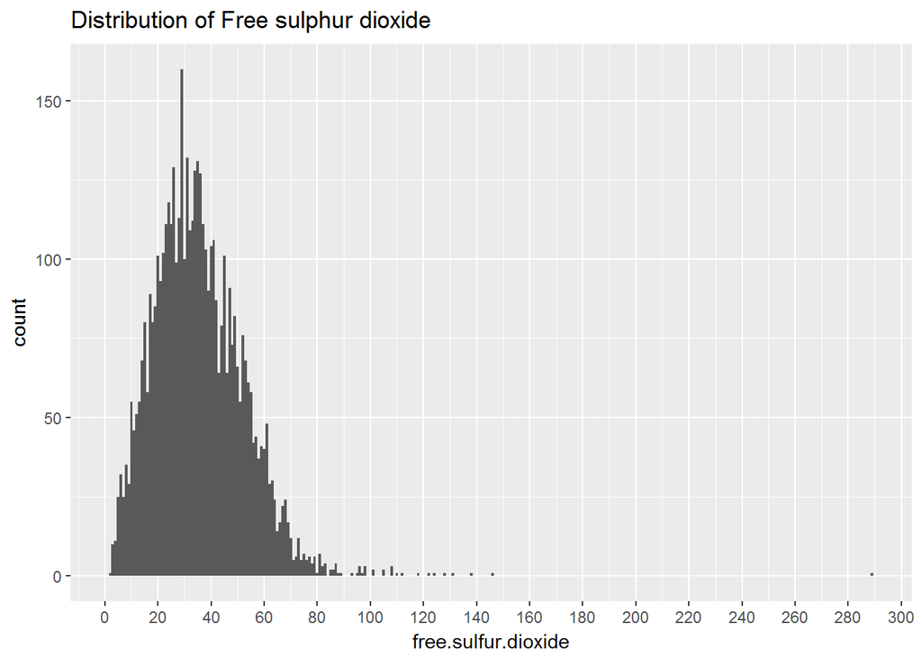

Most of free sulfur dioxide content is between rangte 0 and 80. There are few very high values of free.sulfur.dioxide.

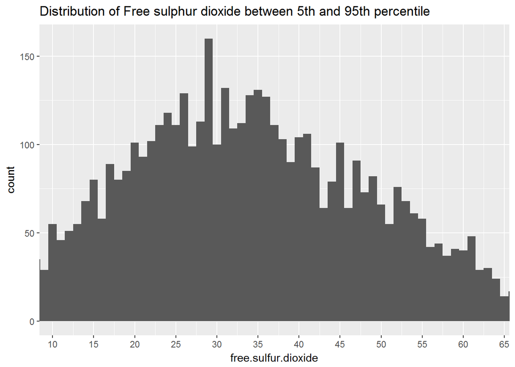

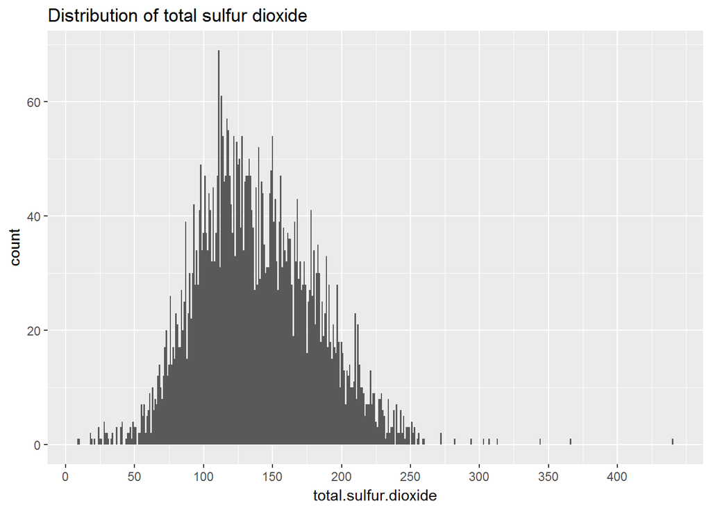

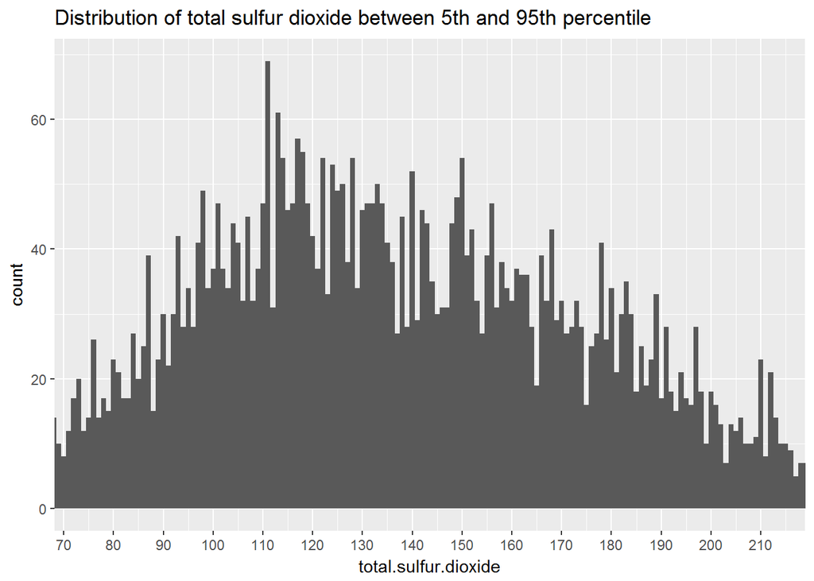

#### Density

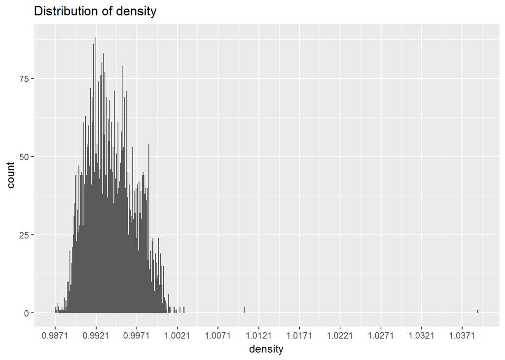

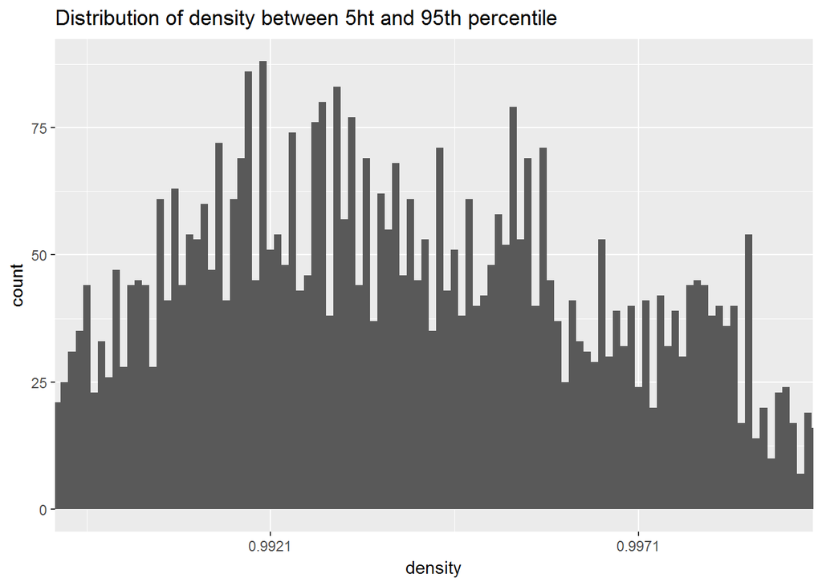

After Removing the outliers,Density distribution is little closer to normal distribution.

#### ph

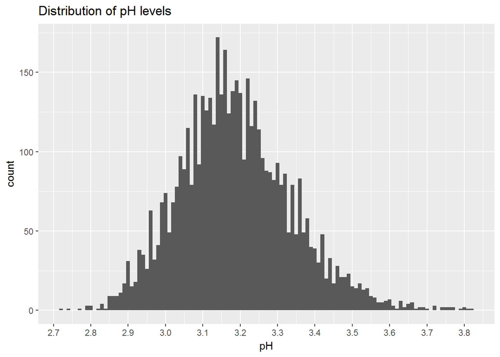

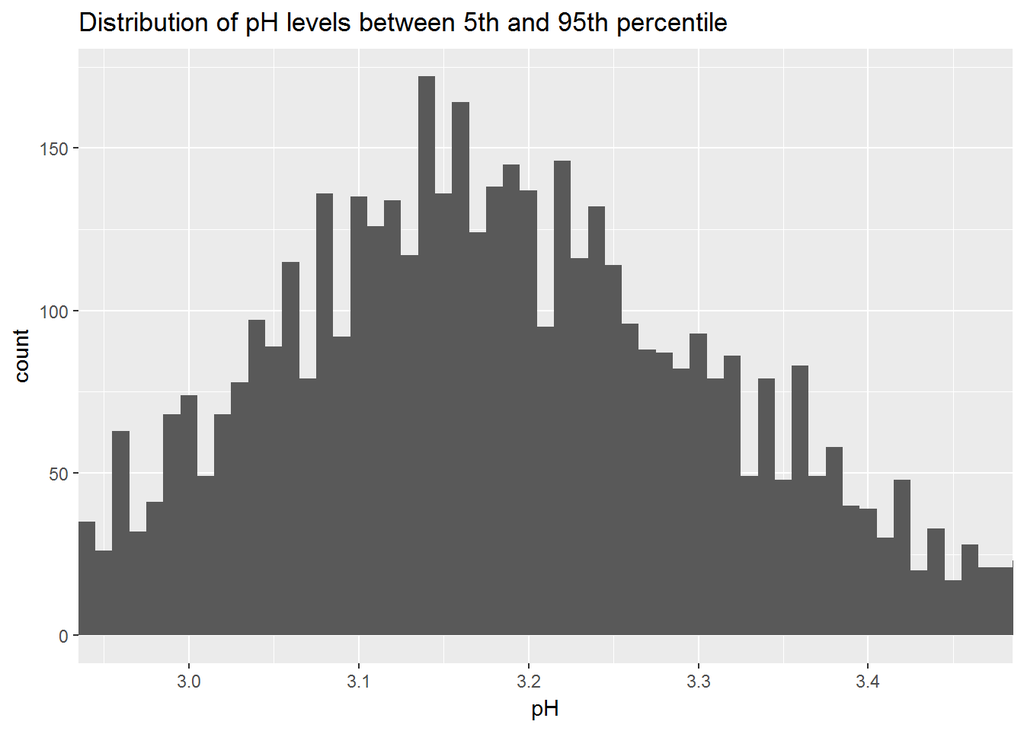

Between 5th and 95th percentile ,pH values follow a normal distribution.

#### sulphates

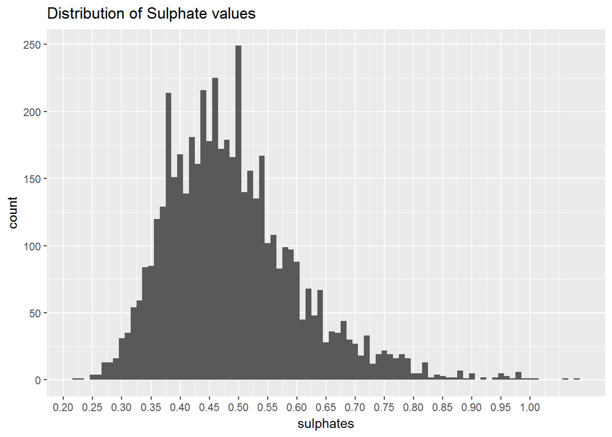

sulphate values lies between 0.2 and 1 values. Most of the suphate values are present between 0.35 to 0.65.

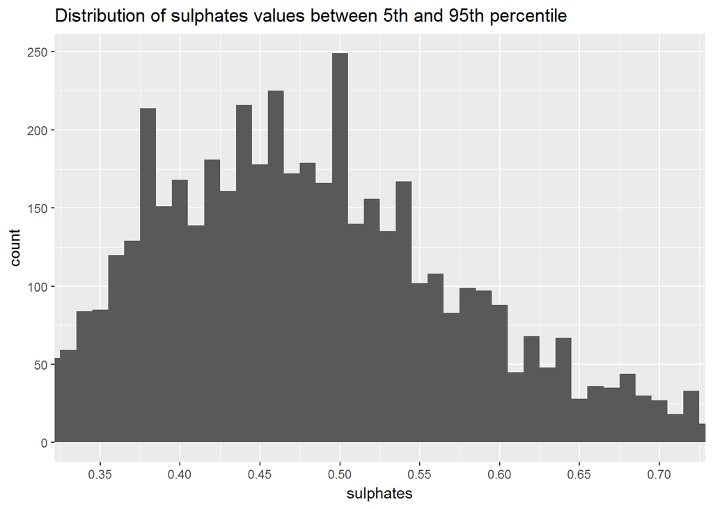

between 5th and 95th percentile ,sulphate values follow a normal distribution.

#### Alcohol

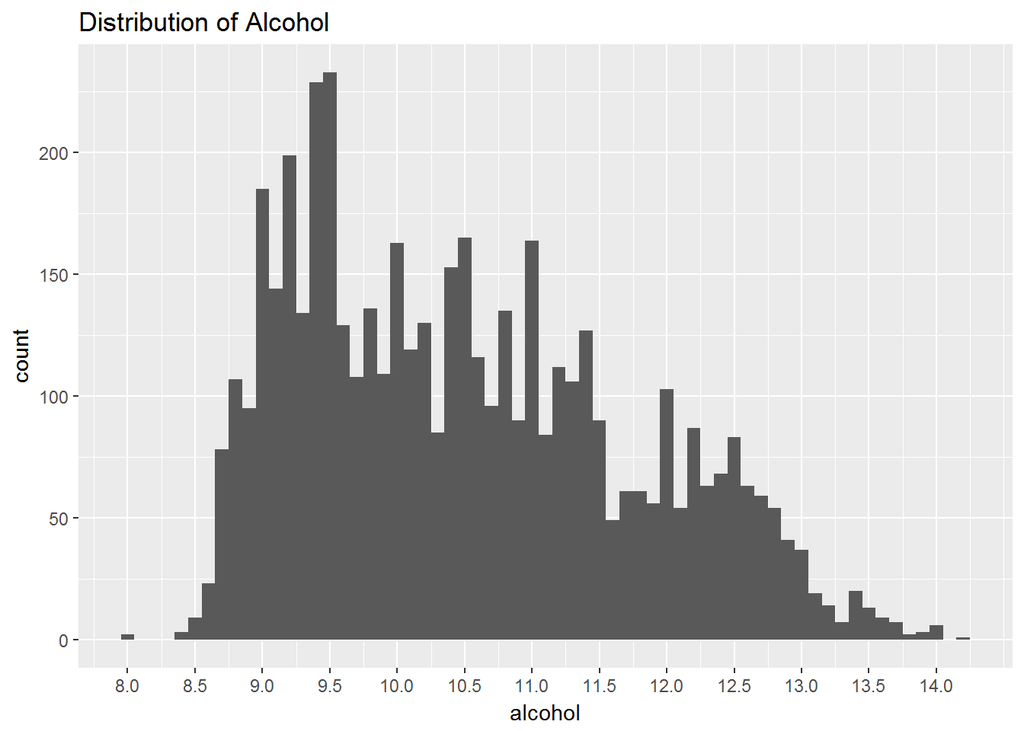

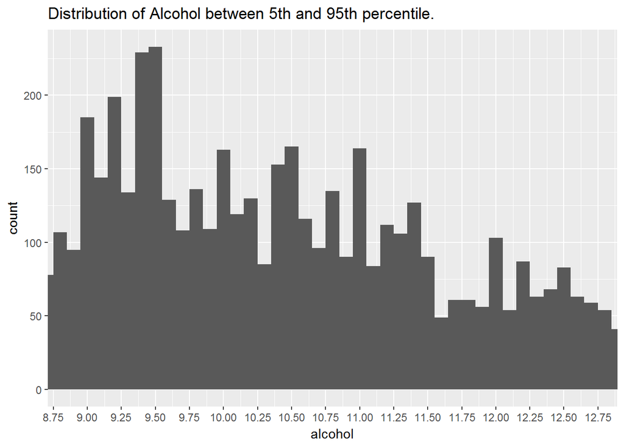

Most of the values of the alcohol are present between 8.75 and 12.75.

#### total acidity

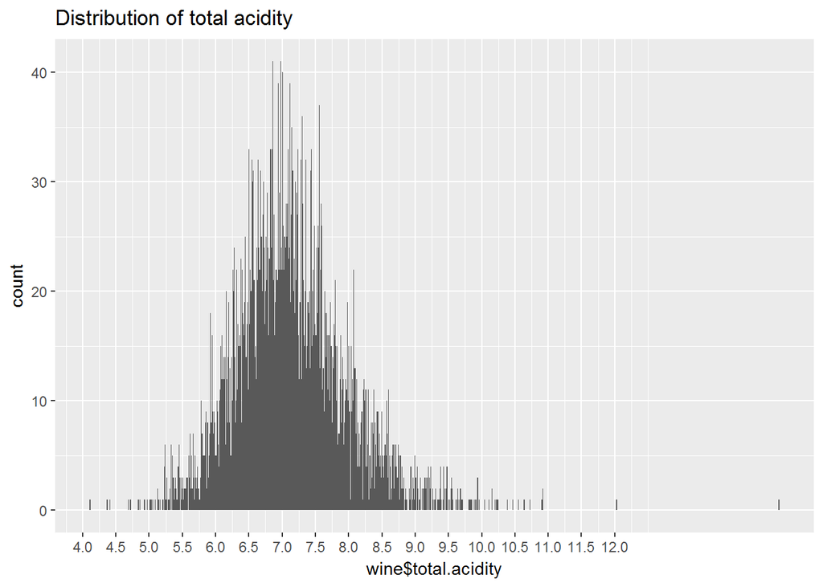

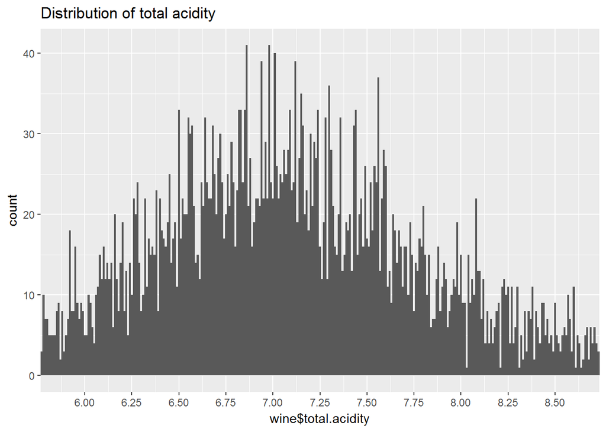

Between 5th and 95th percentile values total acidity follows normal distribution.

# Univariate Analysis

### What is/are the main feature(s) of interest in your dataset?

Almost all of the varialbes(except residual sugar) have a similar distribution.Values between 5th and 95th values follows a normal like distribution.All of the varialbes has values beyond 2 standard deviation from mean. Residual sugar forms a bimodal distribution when scaled by log across x-axis.

### What other features in the dataset do you think will help support your investigation into your feature(s) of interest?

Volatile acidity, total sulphur dioxide,residual sugar are directly related to taste of the wine. Improper proportions of these will lead to bad taste of wine.

### Did you create any new variables from existing variables in the dataset?

Total acidity in the wine is created by combining fixed acidity and volatile acidity. Quality variable is changed from numeric format to factor type.

### Of the features you investigated, were there any unusual distributions? Did you perform any operations on the data to tidy, adjust, or change the form of the data? If so, why did you do this?

All of the varialbes has few values beyond 3 standard deviatations from the mean.When observed between 5th and 95th values, most of these varialbes followed normal distribution.Does the values beyond 3 standard deviation,directly result in very poor or very good wine quality?,this has to futher investigated.

# Bivariate Plots Section

Correlation plot between different variables.

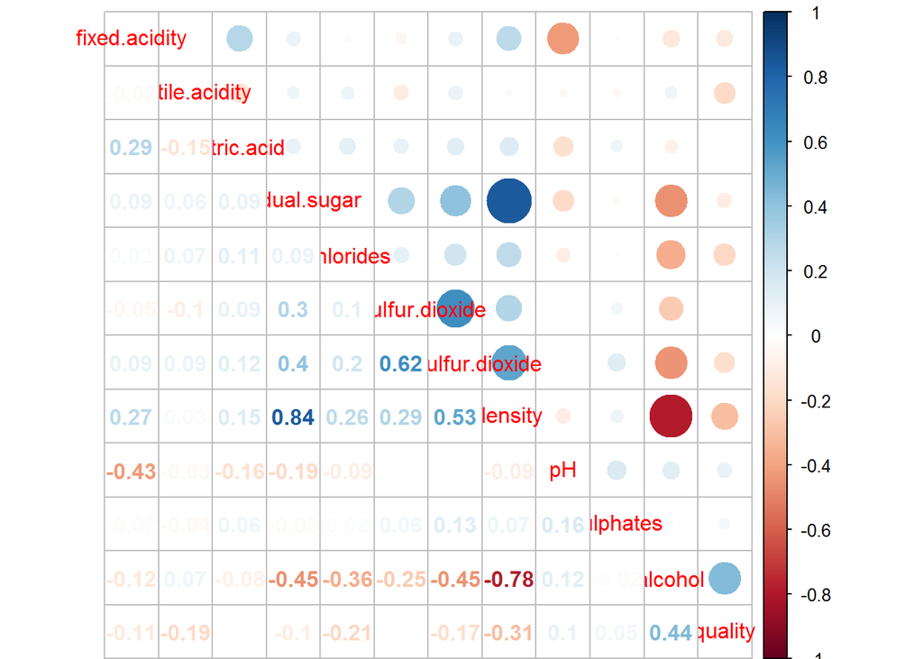

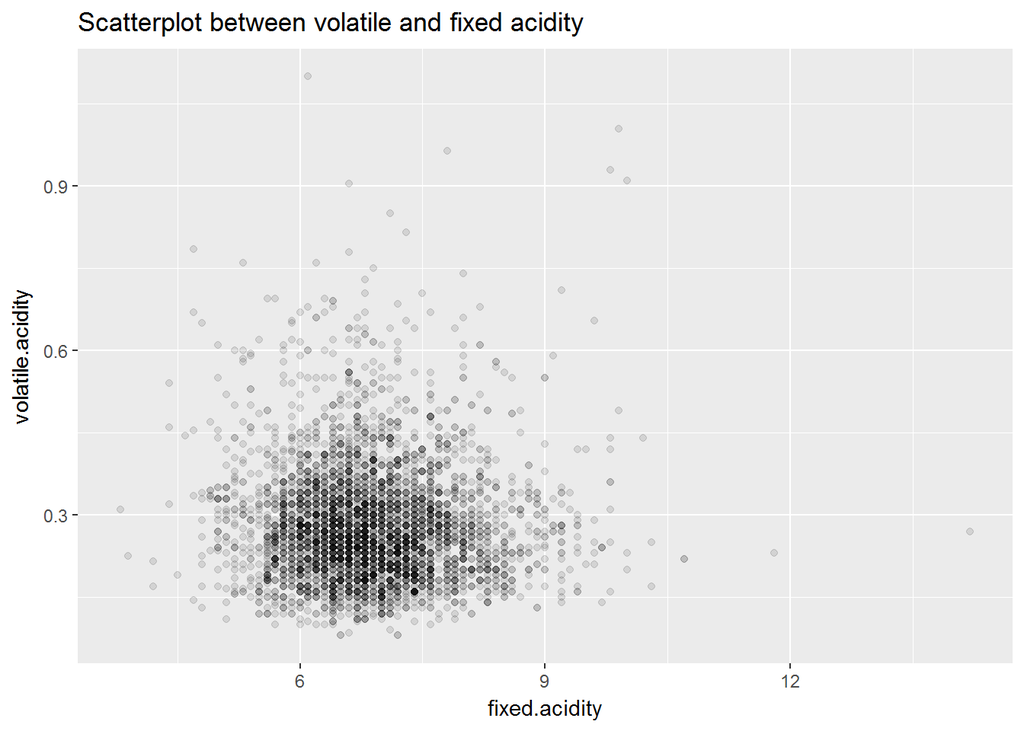

Volatile acidity and fixed acidity does not have any correlation.

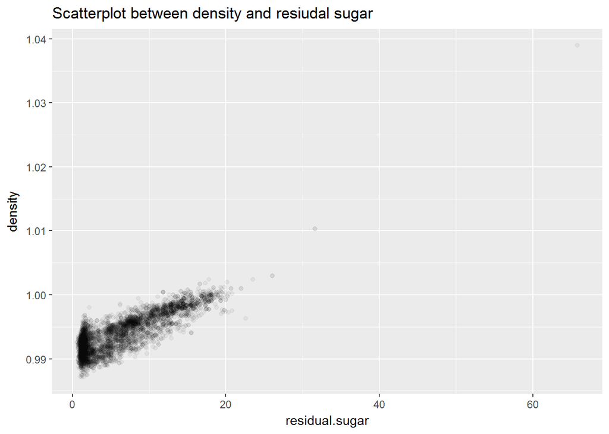

There is clearly a positive correlation between density and residual sugar.

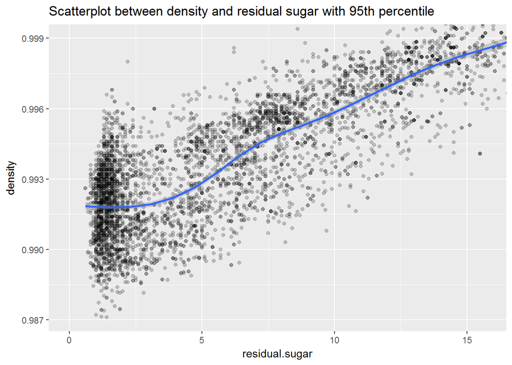

Removing above 95th percentile values from density and residual sugar,shows a clear relationship between density and residual sugar.

[figure not shown]